# Untitled-Copy5

### Data Cleaning

Before any data analysis can be done, data cleaning must be carried out. This is crucial because if the data is not properly cleaned, it’ll impact the results of the statistical computations gotten from the data

### Tools for the Data Analysis

#### We will be using the following python libraries for the data analysis

1. `NumPy:` To carry Numeric Computations like calculating means, medians, sums, and other statistical measures like calculating means, medians, sums, and other statistical measures efficiently.
2. `Pandas:` This is used for data cleaning, preparation, and exploration.
3. `Matplotlib:` It is used to create various types of charts, plots, histograms, scatterplots, and more to visualize data and present findings effectively.
4. `Seaborn:` For creating high-level interface for drawing attractive and informative statistical graphics.

We will be importing all this libraries in the cell below

```python
# Importing the libraries for the data analysis

# Importing the NumPy library and aliasing it as 'np'
import numpy as np

# Importing the Pandas library and aliasing it as 'pd'
import pandas as pd

# Importing the 'pyplot' module from the 'matplotlib' library and aliasing it as 'plt'
from matplotlib import pyplot as plt

# Importing the 'seaborn' library and aliasing it as 'sb'
import seaborn as sns

# This line is a Jupyter Notebook magic command that ensures Matplotlib plots are displayed inline in the notebook
%matplotlib inline
```

```python
# Read the Business-Dataset.csv file into a pandas DataFrame
Dataset = pd.read_csv('Business-Dataset.csv')

# Display only the first 10 rows in the DataFrame
Dataset.head(10)
```

|  | OrderID | ProductID | ProductName | UnitPrice | Duration | TotalSales | CustomerID | First | Last | Email | 2023 Sales Date | Voter | Country | Race | Sex | Education |
| --- | --- | --- | --- | --- | --- | --- | --- | --- | --- | --- | --- | --- | --- | --- | --- | --- |
| 0 | 5 | 105 | Consultation | $ 200.00 | 1 | Please Create a Formula | 113524 | Emma | Green | emma@example.com | 1/10/2023 | Yes | USA | White. | F | PHD |
| 1 | 12 | 105 | Consultation | $ 200.00 | 1 | Please Create a Formula | 113531 | Larry | Harris | larry@example.com | 1/28/2023 | Yes | USA | White. | F | PHD |
| 2 | 19 | 105 | Consultation | $ 200.00 | 1 | Please Create a Formula | 113538 | Sam | Turner | sam@example.com | 2/16/2023 | No | USA | Black or African American. ... | F | Bachelors |
| 3 | 98 | 105 | Consultation | $ 200.00 | 1 | Please Create a Formula | 113617 | Aya | Takahashi | aya.takahashi@example.com | 26-Nov | No | Japan | Indian | F | Bachelors |
| 4 | 99 | 105 | Consultation | $ 200.00 | 1 | Please Create a Formula | 113618 | Zara | Khan | zara.khan@example.com | 26-Nov | No | Afghanistan | Indian | F | Bachelors |
| 5 | 100 | 105 | Consultation | $ 200.00 | 1 | Please Create a Formula | 113619 | Mateo | Morales | mateo.morales@example.com | 26-Nov | No | Mexico | Indian | M | Bachelors |
| 6 | 101 | 105 | Consultation | $ 200.00 | 1 | Please Create a Formula | 113620 | Li Wei | Chen | li.wei@example.com | 26-Nov | No | China | Indian | M | Bachelors |
| 7 | 102 | 105 | Consultation | $ 200.00 | 1 | Please Create a Formula | 113621 | Elena | Ivanova | elena.ivanova@example.com | 26-Nov | No | Bulgaria | Indian | F | Bachelors |
| 8 | 103 | 105 | Consultation | $ 200.00 | 1 | Please Create a Formula | 113622 | Malik | Khan | malik.khan@example.com | 26-Nov | No | Saudi Arabia | Indian | M | Bachelors |
| 9 | 104 | 105 | Consultation | $ 200.00 | 1 | Please Create a Formula | 113623 | Leila | Nour | leila.nour@example.com | 26-Nov | No | Egypt | White. | F | Bachelors |

```python
# Checking if any empty values or missing values are in the entire dataset
total_missing_values = Dataset.isnull().sum().sum()
if total_missing_values == 0:
    print('There are no empty values in the dataset')
else :
    print('There are {} empty values in the dataset'.format(total_missing_values))
```

```
There are no empty values in the dataset
```

## Data Cleaning Report

Since there are no empty values currently, we can proceed with the data cleaning process.

#### Data Cleaning Overview

We'll begin by ensuring that all entries in columns intended to contain numeric values are in the correct format and identifying any outliers. The following columns will be examined as they are expected to hold only numeric data: `OrderID`, `ProductID`, `UnitPrice`, `Duration`, and `CustomerID`.

```python
# List of columns to check for numeric data
columns_to_check = ['OrderID', 'ProductID', 'UnitPrice', 'Duration', 'CustomerID']

# Loop through each column and attempt conversion to numeric
for column in columns_to_check:
    try:
        pd.to_numeric(Dataset[column])
        print(f"\n{column} contains only numeric data.")
    except ValueError:
        print(f"\n{column} contains non-numeric data.")
```

```
OrderID contains only numeric data.

ProductID contains only numeric data.

UnitPrice contains non-numeric data.

Duration contains only numeric data.

CustomerID contains only numeric data.
```

### Data Inspection Report

Upon inspecting all the numeric columns, it was found that only the `UnitPrice` column contains non-numeric data. Consequently, it's essential to convert all the entries in the `UnitPrice` column into numeric values.

```python
# Displaying the first 20 rows in the UnitPrice column
Dataset['UnitPrice'].head(20)
```

```
0      $ 200.00
1      $ 200.00
2      $ 200.00
3      $ 200.00
4      $ 200.00
5      $ 200.00
6      $ 200.00
7      $ 200.00
8      $ 200.00
9      $ 200.00
10     $ 200.00
11     $ 200.00
12     $ 200.00
13     $ 200.00
14     $ 200.00
15     $ 200.00
16     $ 200.00
17     $ 200.00
18     $ 200.00
19     $ 200.00
Name: UnitPrice, dtype: object
```

## Data Cleaning Report

###### Removing `'$'` Symbol from `UnitPrice` Values

To ensure all values in the UnitPrice column are numeric, we need to remove the '$' symbol from the beginning of each value.

```python
# Converts the 'UnitPrice' column to numeric format after replacing any non-numeric characters with an empty string using regex
# Errors parameter set to 'coerce' to convert problematic entries to NaN
Dataset['UnitPrice'] = pd.to_numeric(Dataset['UnitPrice'].replace('[^\d.]', '', regex=True), errors='coerce')

# Displaying the first 20 values in the 'UnitPrice' column
Dataset['UnitPrice'].head(20)
```

```
0     200.0
1     200.0
2     200.0
3     200.0
4     200.0
5     200.0
6     200.0
7     200.0
8     200.0
9     200.0
10    200.0
11    200.0
12    200.0
13    200.0
14    200.0
15    200.0
16    200.0
17    200.0
18    200.0
19    200.0
Name: UnitPrice, dtype: float64
```

## Data Cleaning Report

All Values in the `UnitPrice` Column are so we need to check for `empty` or `Null` values

```python
# Check if for Null or empty values in the 'UnitPrice' column
all_floats = Dataset['UnitPrice'].isnull().sum().sum()
if all_floats == 0:
    print("There are no empty values in the 'UnitPrice' column")
else:
    print(f"There are {all_floats} Null or empty values in the 'UnitPrice' column")
```

```
There are 154 Null or empty values in the 'UnitPrice' column
```

## Data Cleaning Report

### Null Values present in 'UnitPrice' Column

There are `154` `null` or `empty` values present in the `UnitPrice` column.

#### Next Steps

1. **Handling Null Values:** To address the `null` or `empty` values in the `UnitPrice` column, the immediate action will involve converting these nulls to `zeros`. This approach ensures that missing values are replaced with a standardized value `('0')`, facilitating further analysis and computation without losing data points.

```python
# Check if all values in the 'UnitPrice' column are numeric and contain no null value
Dataset['UnitPrice'].fillna(0, inplace=True)
try:
    pd.to_numeric(Dataset['UnitPrice'])
    print("All values in the 'UnitPrice' column are numeric and contains no null or missing values.")
except ValueError:
    print("The 'UnitPrice' column contains non-numeric values.")
```

```
All values in the 'UnitPrice' column are numeric and contains no null or missing values.
```

## Data Cleaning Report

#### 'UnitPrice' Column Numeric Check

All values in the 'UnitPrice' column are in numeric form and contain no null or missing values.

### Next step:

Identifying any `unusual` or `outlier` values within these columns.

```python
# List of numeric columns to check for outliers
numeric_columns = ['OrderID', 'ProductID', 'Duration', 'CustomerID']

# Function to identify outliers based on IQR
def detect_outliers(data):
    outliers = []
    for col in numeric_columns:
        Q1 = data[col].quantile(0.25)
        Q3 = data[col].quantile(0.75)
        IQR = Q3 - Q1
        lower_bound = Q1 - 1.5 * IQR
        upper_bound = Q3 + 1.5 * IQR
        col_outliers = data[(data[col] < lower_bound) | (data[col] > upper_bound)]
        outliers.append(col_outliers)
    return outliers

# Detect outliers in numeric columns
outlier_data = detect_outliers(Dataset)

# Displaying the outliers for each numeric column
for idx, col_name in enumerate(numeric_columns):
    print(f"Outliers in '{col_name}' column:")
    if not outlier_data[idx].empty:
        print("Outliers are present.")
    else:
        print("No outliers found.")
    print("\n")
```

```
Outliers in 'OrderID' column:
No outliers found.


Outliers in 'ProductID' column:
No outliers found.


Outliers in 'Duration' column:
No outliers found.


Outliers in 'CustomerID' column:
No outliers found.
```

## Data Cleaning Report

### Outlier Detection in Numeric Columns

We used the Interquartile Range (IQR) method to identify potential outliers within specified numeric columns in a dataset.

`This code defines a function detect_outliers() that utilizes the Interquartile Range (IQR) method to identify potential outliers for each numeric column specified in the numeric_columns list.`

This methodology assists in flagging potential outlier values that might require further investigation or treatment in the data analysis process

### Outlier Analysis Summary

#### Results

No outliers were detected within the numeric columns

#### Next Step

Our next `task` involves eliminating all leading and trailing `white spaces` while removing any unwanted characters at the end and beginning of `each entry`.

```python
# Identifying and Cleaning String Columns

# Selecting columns containing string data
string_columns = Dataset.select_dtypes(include='object').columns

# Removing '|' character from string columns
Dataset[string_columns] = Dataset[string_columns].apply(lambda x: x.str.replace('|', ''))

import re

# Assuming 'df' is your DataFrame and 'columns_to_check' contains the column names you want to process
columns_to_check = ['ProductName', 'Voter', 'Country', 'Race', 'Sex', 'Education']

# Function to remove non-alphabetic characters and spaces from the beginning and end of entries
def clean_entry(s):
    s = re.sub(r'[^a-zA-Z\s]', '', str(s))  # Remove all non-alphabetic characters and spaces
    return s.strip()  # Remove leading/trailing spaces

# Loop through specified columns
for col in columns_to_check:
    Dataset[col] = Dataset[col].apply(clean_entry)

# Displaying the updated DataFrame
Dataset.tail(50)
```

|  | OrderID | ProductID | ProductName | UnitPrice | Duration | TotalSales | CustomerID | First | Last | Email | 2023 Sales Date | Voter | Country | Race | Sex | Education |
| --- | --- | --- | --- | --- | --- | --- | --- | --- | --- | --- | --- | --- | --- | --- | --- | --- |
| 350 | 189 | 107 | Ultimate Package | 50.0 | 3 | Please Create a Formula | 113708 | Olivia | Chen | olivia.chen@example.com | 26-Nov | No | China | Black or African American | F | No Degree |
| 351 | 190 | 107 | Ultimate Package | 50.0 | 3 | Please Create a Formula | 113709 | Tomás | Fernandez | tomas.fernandez@example.com | 26-Nov | No | Spain | Black or African American | M | No Degree |
| 352 | 191 | 107 | Ultimate Package | 50.0 | 3 | Please Create a Formula | 113710 | Sana | Malik | sana.malik@example.com | 26-Nov | No | Pakistan | Black or African American | F | No Degree |
| 353 | 192 | 107 | Ultimate Package | 50.0 | 3 | Please Create a Formula | 113711 | Ivan | Popov | ivan.popov@example.com | 26-Nov | No | Russia | Black or African American | M | No Degree |
| 354 | 193 | 107 | Ultimate Package | 50.0 | 3 | Please Create a Formula | 113712 | Mei | Wang | mei.wang@example.com | 26-Nov | No | China | Black or African American | F | No Degree |
| 355 | 194 | 107 | Ultimate Package | 50.0 | 3 | Please Create a Formula | 113713 | João | Costa | joao.costa@example.com | 26-Nov | No | Portugal | Black or African American | M | No Degree |
| 356 | 195 | 107 | Ultimate Package | 50.0 | 3 | Please Create a Formula | 113714 | Yui | Ito | yui.ito@example.com | 26-Nov | No | Japan | Black or African American | F | No Degree |
| 357 | 196 | 107 | Ultimate Package | 50.0 | 3 | Please Create a Formula | 113715 | Malik | Ali | malik.ali@example.com | 26-Nov | No | Pakistan | Black or African American | M | No Degree |
| 358 | 197 | 107 | Ultimate Package | 50.0 | 3 | Please Create a Formula | 113716 | Alina | Ivanova | alina.ivanova@example.com | 26-Nov | No | Russia | Black or African American | F | No Degree |
| 359 | 198 | 107 | Ultimate Package | 50.0 | 3 | Please Create a Formula | 113717 | Lorenzo | Moretti | lorenzo.moretti@example.com | 26-Nov | No | Italy | Black or African American | M | No Degree |
| 360 | 199 | 107 | Ultimate Package | 50.0 | 3 | Please Create a Formula | 113718 | Yuki | Nakamura | yuki.nakamura@example.com | 26-Nov | No | Japan | Black or African American | F | No Degree |
| 361 | 200 | 107 | Ultimate Package | 50.0 | 3 | Please Create a Formula | 113719 | Ahmed | Hassan | ahmed.hassan@example.com | 15-May | No | Egypt | Black or African American | M | No Degree |
| 362 | 201 | 107 | Ultimate Package | 50.0 | 3 | Please Create a Formula | 113720 | Mia | Almeida | mia.almeida@example.com | 16-May | No | Brazil | Black or African American | F | No Degree |
| 363 | 202 | 107 | Ultimate Package | 50.0 | 3 | Please Create a Formula | 113721 | Kenji | Tanaka | kenji.tanaka@example.com | 17-May | No | Japan | Black or African American | M | No Degree |
| 364 | 203 | 107 | Ultimate Package | 50.0 | 3 | Please Create a Formula | 113722 | Amina | Ali | amina.ali@example.com | 18-May | No | Pakistan | Black or African American | F | No Degree |
| 365 | 204 | 107 | Ultimate Package | 50.0 | 3 | Please Create a Formula | 113723 | Oliver | Smith | oliver.smith@example.com | 19-May | No | UK | White | M | No Degree |
| 366 | 205 | 107 | Ultimate Package | 50.0 | 3 | Please Create a Formula | 113724 | Mei | Chen | mei.chen@example.com | 20-May | Yes | China | White | F | No Degree |
| 367 | 206 | 107 | Ultimate Package | 50.0 | 3 | Please Create a Formula | 113725 | Leonardo | Costa | leonardo.costa@example.com | 21-May | Yes | Brazil | White | M | PHD |
| 368 | 207 | 107 | Ultimate Package | 50.0 | 3 | Please Create a Formula | 113726 | Sakura | Yamamoto | sakura.yamamoto@example.com | 22-May | Yes | Japan | White | F | PHD |
| 369 | 208 | 107 | Ultimate Package | 50.0 | 3 | Please Create a Formula | 113727 | Zayn | Khan | zayn.khan@example.com | 23-May | Yes | Pakistan | White | M | PHD |
| 370 | 209 | 107 | Ultimate Package | 50.0 | 3 | Please Create a Formula | 113728 | Hanna | Jansen | hanna.jansen@example.com | 24-May | Yes | Netherlands | White | F | PHD |
| 371 | 210 | 107 | Ultimate Package | 50.0 | 3 | Please Create a Formula | 113729 | Kazuki | Suzuki | kazuki.suzuki@example.com | 25-May | Yes | Japan | White | M | PHD |
| 372 | 211 | 107 | Ultimate Package | 50.0 | 3 | Please Create a Formula | 113730 | Fatima | Al-Farsi | fatima.alfarsi@example.com | 26-May | Yes | Saudi Arabia | White | F | PHD |
| 373 | 212 | 107 | Ultimate Package | 50.0 | 3 | Please Create a Formula | 113731 | Enzo | Rossi | enzo.rossi@example.com | 27-May | Yes | Italy | White | M | PHD |
| 374 | 326 | 107 | Ultimate Package | 50.0 | 3 | Please Create a Formula | 113845 | Priya | Verma | priya.verma@example.com | 18-Sep | No | India | White | F | Masters |
| 375 | 327 | 107 | Ultimate Package | 50.0 | 3 | Please Create a Formula | 113846 | Kaito | Watanabe | kaito.watanabe@example.com | 19-Sep | No | Japan | White | M | Masters |
| 376 | 328 | 107 | Ultimate Package | 50.0 | 3 | Please Create a Formula | 113847 | Valentina | Silva | valentina.silva@example.com | 20-Sep | No | Brazil | White | F | Masters |
| 377 | 329 | 107 | Ultimate Package | 50.0 | 3 | Please Create a Formula | 113848 | Hiroki | Yamamoto | hiroki.yamamoto@example.com | 21-Sep | No | Japan | White | M | Masters |
| 378 | 330 | 107 | Ultimate Package | 50.0 | 3 | Please Create a Formula | 113849 | Leila | Malik | leila.malik@example.com | 22-Sep | No | Pakistan | White | F | Masters |
| 379 | 331 | 107 | Ultimate Package | 50.0 | 3 | Please Create a Formula | 113850 | Luca | Moretti | luca.moretti@example.com | 23-Sep | No | Italy | White | M | Masters |
| 380 | 332 | 107 | Ultimate Package | 50.0 | 3 | Please Create a Formula | 113851 | Mei | Wang | mei.wang@example.com | 24-Sep | No | China | White | F | Masters |
| 381 | 333 | 107 | Ultimate Package | 50.0 | 3 | Please Create a Formula | 113852 | Rafael | Costa | rafael.costa@example.com | 25-Sep | No | Portugal | White | M | Masters |
| 382 | 334 | 107 | Ultimate Package | 50.0 | 3 | Please Create a Formula | 113853 | Hana | Suzuki | hana.suzuki@example.com | 26-Sep | No | Japan | White | F | Masters |
| 383 | 335 | 107 | Ultimate Package | 50.0 | 3 | Please Create a Formula | 113854 | Ibrahim | Hassan | ibrahim.hassan@example.com | 27-Sep | No | Egypt | White | M | Masters |
| 384 | 336 | 107 | Ultimate Package | 50.0 | 3 | Please Create a Formula | 113855 | Mia | Almeida | mia.almeida@example.com | 28-Sep | No | Brazil | White | F | Masters |
| 385 | 337 | 107 | Ultimate Package | 50.0 | 3 | Please Create a Formula | 113856 | Yuki | Tanaka | yuki.tanaka@example.com | 29-Sep | No | Japan | White | M | Masters |
| 386 | 338 | 107 | Ultimate Package | 50.0 | 3 | Please Create a Formula | 113857 | Mei | Chang | mei.chang@example.com | 30-Sep | No | China | White | F | Masters |
| 387 | 339 | 107 | Ultimate Package | 50.0 | 3 | Please Create a Formula | 113858 | Akira | Kimura | akira.kimura@example.com | 1-Oct | No | Japan | White | M | Masters |
| 388 | 340 | 107 | Ultimate Package | 50.0 | 3 | Please Create a Formula | 113859 | Emma | Rodriguez | emma.rodriguez@example.com | 2-Oct | No | Spain | White | F | Masters |
| 389 | 341 | 107 | Ultimate Package | 50.0 | 3 | Please Create a Formula | 113860 | Aarav | Verma | aarav.verma@example.com | 3-Oct | No | India | White | M | Masters |
| 390 | 342 | 107 | Ultimate Package | 50.0 | 3 | Please Create a Formula | 113861 | Sophia | Costa | sophia.costa@example.com | 4-Oct | No | Portugal | White | F | Masters |
| 391 | 343 | 107 | Ultimate Package | 50.0 | 3 | Please Create a Formula | 113862 | Kazuki | Nakamura | kazuki.nakamura@example.com | 5-Oct | No | Japan | White | M | Masters |
| 392 | 344 | 107 | Ultimate Package | 50.0 | 3 | Please Create a Formula | 113863 | Yuna | Kim | yuna.kim@example.com | 6-Oct | No | South Korea | White | F | Masters |
| 393 | 345 | 107 | Ultimate Package | 50.0 | 3 | Please Create a Formula | 113864 | Ali | Al-Mansoori | ali.almansoori@example.com | 7-Oct | No | UAE | White | M | Masters |
| 394 | 346 | 107 | Ultimate Package | 50.0 | 1 | Please Create a Formula | 113865 | Sofia | Costa | sofia.costa@example.com | 8-Oct | Yes | Portugal | White | F | Masters |
| 395 | 347 | 107 | Ultimate Package | 50.0 | 1 | Please Create a Formula | 113866 | Hiroshi | Tanaka | hiroshi.tanaka@example.com | 9-Oct | Yes | Japan | White | M | Masters |
| 396 | 348 | 107 | Ultimate Package | 50.0 | 1 | Please Create a Formula | 113867 | Priya | Verma | priya.verma@example.com | 10-Oct | Yes | India | White | F | Masters |
| 397 | 349 | 107 | Ultimate Package | 50.0 | 1 | Please Create a Formula | 113868 | Kaito | Watanabe | kaito.watanabe@example.com | 11-Oct | Yes | Japan | White | M | Masters |
| 398 | 350 | 107 | Ultimate Package | 50.0 | 1 | Please Create a Formula | 113869 | Valentina | Silva | valentina.silva@example.com | 12-Oct | Yes | Brazil | White | F | Masters |
| 399 | 351 | 107 | Ultimate Package | 50.0 | 1 | Please Create a Formula | 113870 | Hiroki | Yamamoto | hiroki.yamamoto@example.com | 13-Oct | Yes | Japan | White | M | Masters |

## Data Cleaning Report :

#### Removing this unwanted Character

The string columns underwent cleaning to eliminate all unwanted character present in each column.

#### Next Steps: Verification of Alphabetic Entries in Name Columns

To ensure data integrity, the next step involves validating the 'First Name' and 'Last Name' columns to verify if they exclusively contain alphabetic characters.

```python
# Function to check if all entries are strings in a column
def check_strings(entry):
    return isinstance(entry, str)

# Check 'First Name' column
if 'First' in Dataset.columns:
    all_strings_first = Dataset['First'].apply(check_strings).all()

    if all_strings_first:
        print("All entries in 'First Name' column contain only alphabets.")
    else:
        print("Not all entries in 'First Name' are alphabets.")


# Check 'Last Name' column
if 'Last' in Dataset.columns:
    all_strings_last = Dataset['Last'].apply(check_strings).all()

    if all_strings_last:
        print("All entries in 'Last Name' column contain only alphabets.")
    else:
        print("Not all entries in 'Last Name' column are alphabets.")
```

[output not shown]

# Data Cleaning Report

## Achieving Name Consistency

### Next Action

Verification of the `Email` column to identify `invalid emails.`

'Invalid emails' are any email address that does not `end with` `@example.com`.

```python
import re
# Function to check if email doesn't end with '@example.com'
def invalid_email(email):
    pattern = re.compile(r'@example\.com\s*$')  # Regex pattern to match emails ending with '@example.com'
    return not pattern.search(email)

# Filtering and printing email addresses that don't end with '@example.com'
invalid_emails = Dataset[Dataset['Email'].apply(invalid_email)]
if not invalid_emails.empty:
    print(f"There are {len(invalid_emails)} email adresses that don't end with '@example.com':")

else:
    print("All email addresses end with '@example.com'.")
```

```
There are 7 email adresses that don't end with '@example.com':
```

```python
# Dsplaying all the invalid emails
invalid_emails
```

|  | OrderID | ProductID | ProductName | UnitPrice | Duration | TotalSales | CustomerID | First | Last | Email | 2023 Sales Date | Voter | Country | Race | Sex | Education |
| --- | --- | --- | --- | --- | --- | --- | --- | --- | --- | --- | --- | --- | --- | --- | --- | --- |
| 41 | 123 | 102 | Family Package | 45.0 | 3 | Please Create a Formula | 113642 | Alejandro | Gutierrez | alejandro.gutierrez@example.c | 26-Nov | Yes | Mexico | White | M | No Degree |
| 66 | 44 | 106 | Free Membership | 0.0 | 12 | Please Create a Formula | 113563 | Carlos | Rodriguez | carlos.rodriguez@example.co | 26-Nov | No | Spain | Hispanic or Latino | M | Highschool |
| 84 | 62 | 106 | Free Membership | 0.0 | 12 | Please Create a Formula | 113581 | Gabriela | Hernandez | gabriela.hernandez@example. | 26-Nov | No | Mexico | Hispanic or Latino | F | Bachelors |
| 87 | 65 | 106 | Free Membership | 0.0 | 12 | Please Create a Formula | 113584 | Guilherme | Oliveira | guilherme.oliveira@example.c | 26-Nov | No | Brazil | White | M | No Degree |
| 91 | 69 | 106 | Free Membership | 0.0 | 12 | Please Create a Formula | 113588 | Hiroshi | Takahashi | hiroshi.takahashi@example.c | 26-Nov | No | Japan | Asian | M | Highschool |
| 99 | 77 | 106 | Free Membership | 0.0 | 12 | Please Create a Formula | 113596 | Javier | Fernandez | javier.fernandez@example.co | 26-Nov | No | Spain | Hispanic or Latino | M | Highschool |
| 347 | 186 | 107 | Ultimate Package | 50.0 | 3 | Please Create a Formula | 113705 | Leo | Silva | leo.silva@example | 26-Nov | No | Brazil | Black or African American | M | No Degree |

# Data Cleaning Report

There exist `7` instances of `invalid emails` within the dataset.

### Next Step

The following step involves converting and rectifying all identified `invalid emails` to ensure they conclude with `@example.com`.

```python
# Function to fix invalid email addresses
def fix_invalid_emails(email):
    if not email.endswith('@example.com'):
        email = email.split('@')[0] + '@example.com'  # Replace domain with @example.com
    return email

# Applying the function to update invalid email addresses
Dataset.loc[:, 'Email'] = Dataset['Email'].apply(fix_invalid_emails)
```

## Data Cleaning Report

Every `email address` has been standardized to `end with` `@example.com`.

### Next Step

Adjusting the `dates` to adhere to this format: `(Month/Date/Full Year)`.

```python
# Function to standardize dates
def standardize_date(date):
    # Check if date contains '/'
    if '/' in date:
        return pd.to_datetime(date).strftime('%m/%d/%Y')
    else:
        return pd.to_datetime(date + '/2023').strftime('%m/%d/%Y')

# Apply the function to standardize the dates in the '2023 Sales Date' column
Dataset['2023 Sales Date'] = Dataset['2023 Sales Date'].apply(standardize_date)

# Display the first 10 rows
Dataset.head(10)
```

|  | OrderID | ProductID | ProductName | UnitPrice | Duration | TotalSales | CustomerID | First | Last | Email | 2023 Sales Date | Voter | Country | Race | Sex | Education |
| --- | --- | --- | --- | --- | --- | --- | --- | --- | --- | --- | --- | --- | --- | --- | --- | --- |
| 0 | 5 | 105 | Consultation | 200.0 | 1 | Please Create a Formula | 113524 | Emma | Green | emma@example.com | 01/10/2023 | Yes | USA | White | F | PHD |
| 1 | 12 | 105 | Consultation | 200.0 | 1 | Please Create a Formula | 113531 | Larry | Harris | larry@example.com | 01/28/2023 | Yes | USA | White | F | PHD |
| 2 | 19 | 105 | Consultation | 200.0 | 1 | Please Create a Formula | 113538 | Sam | Turner | sam@example.com | 02/16/2023 | No | USA | Black or African American | F | Bachelors |
| 3 | 98 | 105 | Consultation | 200.0 | 1 | Please Create a Formula | 113617 | Aya | Takahashi | aya.takahashi@example.com | 11/26/2023 | No | Japan | Indian | F | Bachelors |
| 4 | 99 | 105 | Consultation | 200.0 | 1 | Please Create a Formula | 113618 | Zara | Khan | zara.khan@example.com | 11/26/2023 | No | Afghanistan | Indian | F | Bachelors |
| 5 | 100 | 105 | Consultation | 200.0 | 1 | Please Create a Formula | 113619 | Mateo | Morales | mateo.morales@example.com | 11/26/2023 | No | Mexico | Indian | M | Bachelors |
| 6 | 101 | 105 | Consultation | 200.0 | 1 | Please Create a Formula | 113620 | Li Wei | Chen | li.wei@example.com | 11/26/2023 | No | China | Indian | M | Bachelors |
| 7 | 102 | 105 | Consultation | 200.0 | 1 | Please Create a Formula | 113621 | Elena | Ivanova | elena.ivanova@example.com | 11/26/2023 | No | Bulgaria | Indian | F | Bachelors |
| 8 | 103 | 105 | Consultation | 200.0 | 1 | Please Create a Formula | 113622 | Malik | Khan | malik.khan@example.com | 11/26/2023 | No | Saudi Arabia | Indian | M | Bachelors |
| 9 | 104 | 105 | Consultation | 200.0 | 1 | Please Create a Formula | 113623 | Leila | Nour | leila.nour@example.com | 11/26/2023 | No | Egypt | White | F | Bachelors |

## Data Cleaning Report

All the `dates`have been adjusted to this format: `(Month/Date/Full Year)`.

#### Next Step

Our next `task` involves eliminating all leading and trailing `white spaces` while removing any unwanted characters at the end of `each entry`.

```python
columns_to_check = ['ProductName', 'Voter', 'Country', 'Race', 'Sex', 'Education']

# Function to remove non-alphabetic characters from the end of entries
def remove_non_alphabet(s):
    while s and not s[-1].isalpha():
        s = s[:-1]
    return s

# Loop through specified columns
for col in columns_to_check:
    Dataset[col] = Dataset[col].apply(lambda x: remove_non_alphabet(str(x)) if isinstance(x, str) else x)
```

## Data Cleaning Report

All leading and trailing `white spaces` and any unwanted characters at the end of `each entry` have been eliminated.

#### Next Step

Organize the data to get insights into voter habits.

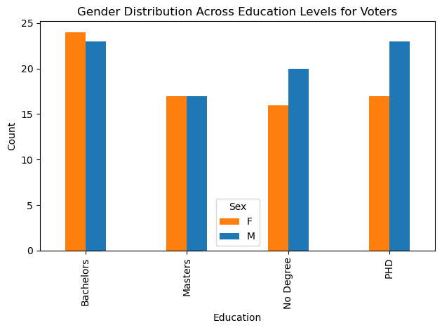

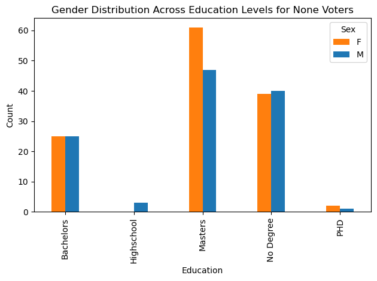

```python
yes_voters = Dataset[Dataset['Voter'] == 'Yes']  # Filter for 'Yes' voters
no_voters = Dataset[Dataset['Voter'] == 'No']


# Group 'Yes' voters based on education and sex
grouped_yes_voters = yes_voters.groupby(['Education', 'Sex']).size().unstack(fill_value=0)

# Rearranging the DataFrame to have male and female counts side by side for each education level
grouped_yes_voters['Total'] = grouped_yes_voters['F'] + grouped_yes_voters['M']
grouped_yes_voters = grouped_yes_voters[['F', 'M', 'Total']]

# Plotting grouped bar chart for 'Yes' voters by education and sex
plt.figure(figsize=(10, 6))
grouped_yes_voters[['F', 'M']].plot(kind='bar', stacked=False, color=['#ff7f0e', '#1f77b4'], width=0.4)
plt.title("Gender Distribution Across Education Levels for Voters")
plt.xlabel('Education')
plt.ylabel('Count')
plt.legend(title='Sex')
plt.tight_layout()


# Group 'No' voters based on education and sex
grouped_no_voters = no_voters.groupby(['Education', 'Sex']).size().unstack(fill_value=0)

# Rearranging the DataFrame to have male and female counts side by side for each education level
grouped_no_voters['Total'] = grouped_no_voters['F'] + grouped_no_voters['M']
grouped_no_voters = grouped_no_voters[['F', 'M', 'Total']]

# Plotting grouped bar chart for 'No' voters by education and sex
plt.figure(figsize=(10, 6))
grouped_no_voters[['F', 'M']].plot(kind='bar', stacked=False, color=['#ff7f0e', '#1f77b4'], width=0.4)
plt.title("Gender Distribution Across Education Levels for None Voters")
plt.xlabel('Education')
plt.ylabel('Count')
plt.legend(title='Sex')
plt.tight_layout()
plt.show()
```

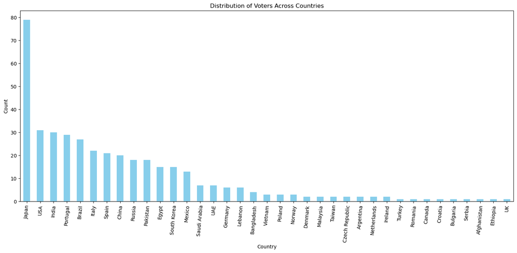

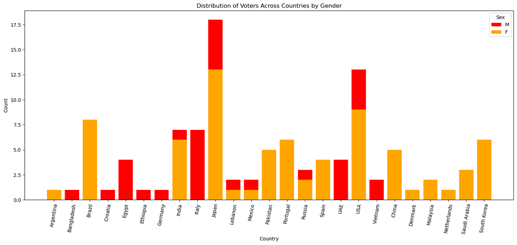

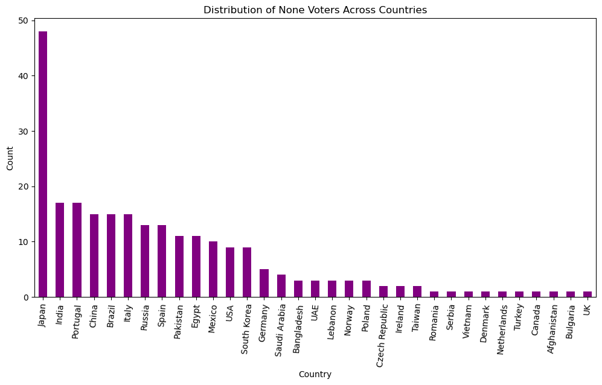

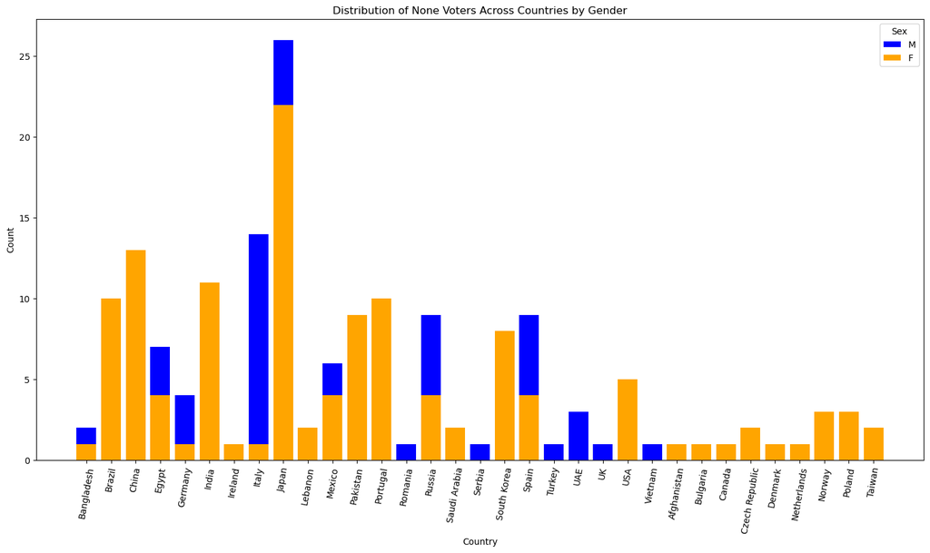

```python
country_distribution = Dataset['Country'].value_counts()

plt.figure(figsize=(18, 7))
country_distribution.plot(kind='bar', color='skyblue')
plt.title("Distribution of Voters Across Countries")
plt.xlabel('Country')
plt.ylabel('Count')
plt.xticks(rotation=85)
plt.show()
# Filter 'Yes' voters by gender
filtered_yes_voters = yes_voters[yes_voters['Sex'].isin(['M', 'F'])]

# Get the count of 'Yes' voters by country and gender
country_counts = filtered_yes_voters.groupby(['Country', 'Sex']).size().reset_index(name='Count')

# Calculate total count of 'Yes' voters per country
total_counts = country_counts.groupby('Country')['Count'].sum().reset_index(name='TotalCount')

# Sort countries by the total count of 'Yes' voters in descending order
sorted_countries = total_counts.sort_values(by='TotalCount', ascending=False)['Country']

# Plotting the count of 'Yes' voters across countries by gender using Matplotlib
plt.figure(figsize=(18, 7))
for sex in ['M', 'F']:
    data = country_counts[country_counts['Sex'] == sex]
    sorted_data = data[data['Country'].isin(sorted_countries)]  # Align data with sorted countries
    plt.bar(sorted_data['Country'], sorted_data['Count'], label=sex, color='red' if sex == 'M' else 'orange')

plt.title('Distribution of Voters Across Countries by Gender')
plt.xlabel('Country')
plt.ylabel('Count')
plt.xticks(rotation=80)
plt.legend(title='Sex', loc='upper right')
plt.show()



# Get the count of 'No' voters by country
country_distribution_no = no_voters['Country'].value_counts()

plt.figure(figsize=(12, 6))
country_distribution_no.plot(kind='bar', color='purple')
plt.title("Distribution of None Voters Across Countries")
plt.xlabel('Country')
plt.ylabel('Count')
plt.xticks(rotation=85)
plt.show()


# Filter 'No' voters by gender
filtered_no_voters = no_voters[no_voters['Sex'].isin(['M', 'F'])]

# Get the count of 'No' voters by country and gender
country_counts_no = filtered_no_voters.groupby(['Country', 'Sex']).size().reset_index(name='Count')

# Calculate total count of 'No' voters per country
total_counts_no = country_counts_no.groupby('Country')['Count'].sum().reset_index(name='TotalCount')

# Sort countries by the total count of 'No' voters in descending order
sorted_countries_no = total_counts_no.sort_values(by='TotalCount', ascending=False)['Country']

# Plotting the count of 'No' voters across countries by gender using Matplotlib
plt.figure(figsize=(18, 9))
for sex in ['M', 'F']:
    data_no = country_counts_no[country_counts_no['Sex'] == sex]
    sorted_data_no = data_no[data_no['Country'].isin(sorted_countries_no)]
    plt.bar(sorted_data_no['Country'], sorted_data_no['Count'], label=sex, color='blue' if sex == 'M' else 'orange')

plt.title('Distribution of None Voters Across Countries by Gender')
plt.xlabel('Country')
plt.ylabel('Count')
plt.xticks(rotation=80)
plt.legend(title='Sex', loc='upper right')
plt.show()
```

[figure not shown]

[figure not shown]

```python
# Get race counts for 'Yes' and 'No' voters
race_counts_yes = yes_voters['Race'].value_counts()
race_counts_no = no_voters['Race'].value_counts()

# Plotting pie chart for 'Yes' voters by race
plt.figure(figsize=(8, 8))
plt.pie(race_counts_yes, labels=race_counts_yes.index, autopct='%1.1f%%', startangle=140)
plt.title('Distribution of Voters by Race')
plt.axis('equal')
plt.show()

# Plotting pie chart for 'No' voters by race
plt.figure(figsize=(8, 8))
plt.pie(race_counts_no, labels=race_counts_no.index, autopct='%1.1f%%', startangle=140)
plt.title('Distribution of None Voters by Race')
plt.axis('equal')
plt.show()
```

### Shifting the `date` column and making it the first column and arranging the rows by `OrderID`

```python
columns = Dataset.columns.tolist()
columns = ['2023 Sales Date'] + [col for col in columns if col != '2023 Sales Date']  # Shifting '2023 Sales Date' to the front
Dataset = Dataset[columns]

# Sort the DataFrame by 'Order ID' in ascending order
Dataset = Dataset.sort_values('OrderID')

# Display the first 10 rows
Dataset.head(10)
```

|  | 2023 Sales Date | OrderID | ProductID | ProductName | UnitPrice | Duration | TotalSales | CustomerID | First | Last | Email | Voter | Country | Race | Sex | Education |
| --- | --- | --- | --- | --- | --- | --- | --- | --- | --- | --- | --- | --- | --- | --- | --- | --- |
| 280 | 01/01/2023 | 1 | 101 | Single Membership | 5.0 | 12 | Please Create a Formula | 113520 | Alice | Johnson | alice@example.com | Yes | USA | White | F | PHD |
| 37 | 01/03/2023 | 2 | 102 | Family Package | 45.0 | 1 | Please Create a Formula | 113521 | Bob | Smith | bob@example.com | Yes | USA | White | M | PHD |
| 210 | 01/05/2023 | 3 | 103 | Friendship Package | 30.0 | 12 | Please Create a Formula | 113522 | Charlie | Brown | charlie@example.com | Yes | USA | White | M | PHD |
| 239 | 01/08/2023 | 4 | 104 | HoneyMoon Package | 10.0 | 3 | Please Create a Formula | 113523 | David | White | david@example.com | Yes | USA | White | M | PHD |
| 0 | 01/10/2023 | 5 | 105 | Consultation | 200.0 | 1 | Please Create a Formula | 113524 | Emma | Green | emma@example.com | Yes | USA | White | F | PHD |
| 56 | 01/12/2023 | 6 | 106 | Free Membership | 0.0 | 12 | Please Create a Formula | 113525 | Frank | Black | frank@example.com | Yes | USA | White | M | PHD |
| 313 | 02/11/2023 | 7 | 107 | Ultimate Package | 50.0 | 1 | Please Create a Formula | 113526 | Tina | Turner | tina@example.com | Yes | USA | White | F | PHD |
| 281 | 01/18/2023 | 8 | 101 | Single Membership | 5.0 | 12 | Please Create a Formula | 113527 | Henry | Young | henry@example.com | Yes | USA | White | M | PHD |
| 38 | 01/20/2023 | 9 | 102 | Family Package | 45.0 | 3 | Please Create a Formula | 113528 | Irene | Adams | irene@example.com | Yes | USA | White | M | PHD |
| 211 | 01/22/2023 | 10 | 103 | Friendship Package | 30.0 | 12 | Please Create a Formula | 113529 | Jack | Miller | jack@example.com | Yes | USA | White | F | PHD |

### Replacing F and M in Sex Column with Female and Male Respectively

```python
# Replacing values with leading/trailing spaces and variations
Dataset['Sex'] = Dataset['Sex'].str.strip().replace({'F': 'Female', 'M': 'Male', ' F': 'Female', ' M': 'Male'})

# Displaying the updated 'Sex' column
print(Dataset['Sex'].unique())
```

```
['Female' 'Male']
```

## Checking for Duplicate rows

#### Results : `No duplicate Rows found`

```python
# Assuming 'df' is your DataFrame
duplicate_rows = Dataset[Dataset.duplicated()]

# Displaying duplicate rows (if any)
if duplicate_rows.empty:
    print("No duplicate rows found.")
else:
    print("Duplicate rows found:")
```

```
No duplicate rows found.
```

```python
# Calculating the Total Sales
Dataset['TotalSales'] = Dataset['UnitPrice'] * Dataset['Duration']
```

## Data Analysis Report

The `TotalSales` column has been calculated by multiplying the values from `Duration` column and `UnitPrice` column.

### Next Steps : `Creation of Pivot Tables`

The Pandas library already has a built-in function called `pivot_table` to create pivot tables.

#### Multiple `Pivot tables` will be created using the built in pivot table function

```python
pivot_table_1 = Dataset.pivot_table(values='TotalSales', index='Country', aggfunc='sum')
print("\nPivot Table 1 - Total Sales by Country:")
pivot_table_1
```

```
Pivot Table 1 - Total Sales by Country:
```

| Country | TotalSales |
| --- | --- |
| Afghanistan | 200.0 |
| Argentina | 630.0 |
| Bangladesh | 290.0 |
| Brazil | 1835.0 |
| Bulgaria | 200.0 |
| Canada | 0.0 |
| China | 1590.0 |
| Croatia | 270.0 |
| Czech Republic | 110.0 |
| Denmark | 360.0 |
| Egypt | 1135.0 |
| Ethiopia | 60.0 |
| Germany | 200.0 |
| India | 2400.0 |
| Ireland | 0.0 |
| Italy | 1610.0 |
| Japan | 6190.0 |
| Lebanon | 140.0 |
| Malaysia | 30.0 |
| Mexico | 695.0 |
| Netherlands | 150.0 |
| Norway | 150.0 |
| Pakistan | 1310.0 |
| Poland | 110.0 |
| Portugal | 1750.0 |
| Romania | 0.0 |
| Russia | 1070.0 |
| Saudi Arabia | 770.0 |
| Serbia | 360.0 |
| South Korea | 920.0 |
| Spain | 1200.0 |
| Taiwan | 0.0 |
| Turkey | 0.0 |
| UAE | 875.0 |
| UK | 150.0 |
| USA | 3085.0 |
| Vietnam | 0.0 |

```python
pivot_table_2 = Dataset.pivot_table(values='UnitPrice', index='ProductName', aggfunc='mean')
print("\nPivot Table 2 - Average Unit Price by Product:")
pivot_table_2
```

```
Pivot Table 2 - Average Unit Price by Product:
```

| ProductName | UnitPrice |
| --- | --- |
| Consultation | 200.0 |
| Family Package | 45.0 |
| Free Membership | 0.0 |
| Friendship Package | 30.0 |
| HoneyMoon Package | 10.0 |
| Single Membership | 5.0 |
| Ultimate Package | 50.0 |

```python
pivot_table_3 = Dataset.pivot_table(values='TotalSales', index='Race', columns='Sex', aggfunc='sum', fill_value=0)
print("\nPivot Table 3 - Total Sales by Race and Sex:")
pivot_table_3
```

```
Pivot Table 3 - Total Sales by Race and Sex:
```

| Sex Race | Female | Male |
| --- | --- | --- |
| Asian | 750.0 | 500.0 |
| Black or African American | 2405.0 | 2920.0 |
| Hispanic or Latino | 0.0 | 0.0 |
| Indian | 600.0 | 650.0 |
| LatinAm | 150.0 | 50.0 |
| Native Hawaiian or Other Pacific Islander | 200.0 | 400.0 |
| White | 10510.0 | 10710.0 |

```python
pivot_table_4 = Dataset.pivot_table(values='OrderID', index='Education', aggfunc='count')
print("\nPivot Table 4 - Count of Orders by Education:")
pivot_table_4
```

```
Pivot Table 4 - Count of Orders by Education:
```

| Education | OrderID |
| --- | --- |
| Bachelors | 97 |
| Highschool | 3 |
| Masters | 142 |
| No Degree | 115 |
| PHD | 43 |

```python
# Grouping data by 'Region' and calculating total profit for each region
profit_by_region = Dataset.groupby('Country')['TotalSales'].sum().reset_index()

# Finding the region with the highest profit
most_profitable_region = profit_by_region.loc[profit_by_region['TotalSales'].idxmax()]

print("The region bringing in the most profit is:", most_profitable_region['Country'])
print("Total Profit in that region:", most_profitable_region['TotalSales'])
```

```
The region bringing in the most profit is: Japan
Total Profit in that region: 6190.0
```

```python
# Assuming 'Dataset' is your DataFrame with 'Country' and 'TotalSales' columns

# Grouping data by 'Country' and calculating total sales for each country
sales_by_country = Dataset.groupby('Country')['TotalSales'].sum().reset_index()

# Sorting data by TotalSales to find the least profitable regions
sorted_least_profitable_regions = sales_by_country.sort_values('TotalSales').head(6)

print("The least profitable regions:")
sorted_least_profitable_regions
```

```
The least profitable regions:
```

|  | Country | TotalSales |
| --- | --- | --- |
| 36 | Vietnam | 0.0 |
| 32 | Turkey | 0.0 |
| 31 | Taiwan | 0.0 |
| 25 | Romania | 0.0 |
| 14 | Ireland | 0.0 |
| 5 | Canada | 0.0 |

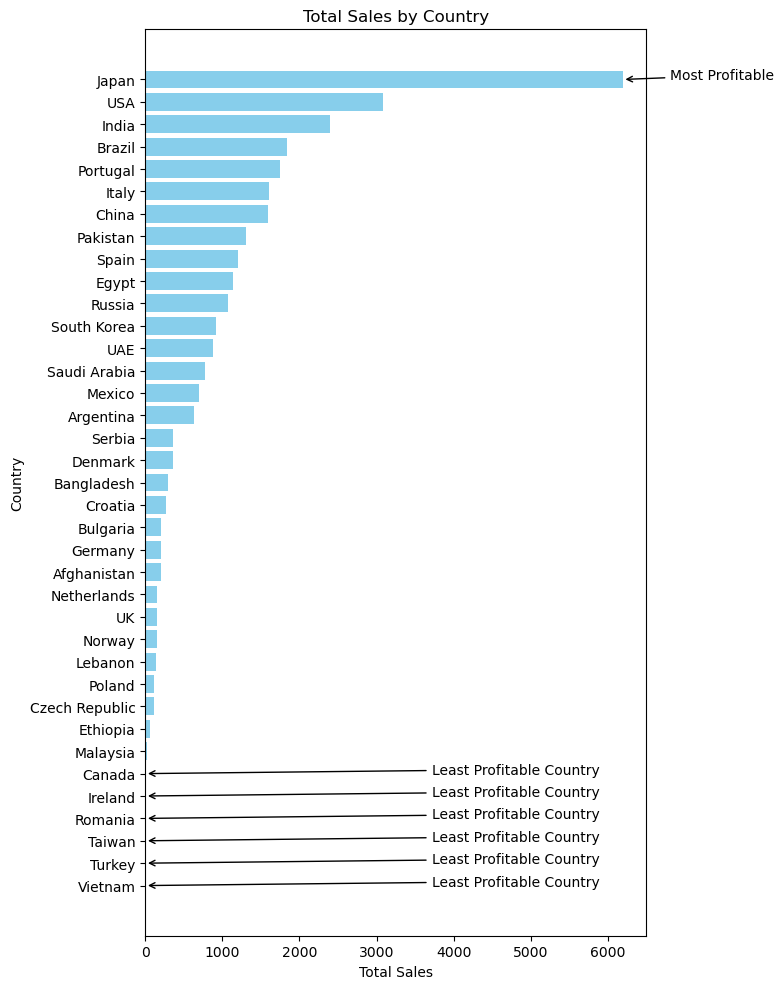

```python
import matplotlib.pyplot as plt

# Grouping data by 'Country' and calculating total sales for each country
sales_by_country = Dataset.groupby('Country')['TotalSales'].sum().reset_index()

# Sorting data by TotalSales to have a clearer visualization
sales_by_country = sales_by_country.sort_values('TotalSales', ascending=True)

# Plotting the data
plt.figure(figsize=(8, 10))

# Assigning a different color to the least profitable countries
bar_colors = ['skyblue' if country not in sales_by_country['Country'].head(5).tolist() else 'salmon' for country in sales_by_country['Country']]

plt.barh(sales_by_country['Country'], sales_by_country['TotalSales'], color=bar_colors)
plt.xlabel('Total Sales')
plt.ylabel('Country')
plt.title('Total Sales by Country')

# Highlighting most profitable and least profitable countries
most_profitable_country = sales_by_country['Country'].iloc[-1]
least_profitable_countries = sales_by_country['Country'].head(6)

for country in least_profitable_countries:
    plt.annotate('Least Profitable Country',
                 xy=(sales_by_country[sales_by_country['Country'] == country]['TotalSales'], country),
                 xytext=(sales_by_country['TotalSales'].max() * 0.6, country),
                 arrowprops=dict(facecolor='black', arrowstyle='->'))

most_profitable_country = sales_by_country['Country'].iloc[-1]
plt.annotate('Most Profitable',
             xy=(float(sales_by_country['TotalSales'].iloc[-1]), sales_by_country['Country'].iloc[-1]),
             xytext=(float(sales_by_country['TotalSales'].iloc[-1]) * 1.1, len(sales_by_country) - 1),
             arrowprops=dict(facecolor='black', arrowstyle='->'))

plt.tight_layout()
plt.show()
```

### Caculating Correlation between Less Educated Voters and More Educated Voters

```python
from scipy.stats import chi2_contingency


# Creating subsets for educated and less educated voters
educated_voters = Dataset[Dataset['Education'] != 'No Degree']
less_educated_voters = Dataset[Dataset['Education'] == 'No Degree']

# Creating a contingency table
contingency_table = pd.crosstab(Dataset['Education'], Dataset['Voter'])

# Performing chi-squared test for independence
chi2, p, dof, expected = chi2_contingency(contingency_table)

# Setting significance level
alpha = 0.05

# Checking for correlation
if p < alpha:
    print("There is a significant correlation between educated and less educated voters.")
else:
    print("There is no significant correlation between educated and less educated voters.")
```

```
There is a significant correlation between educated and less educated voters.
```

```python
dataset = Dataset
# Mapping education levels to 'Educated' and 'Less Educated'
dataset['Education_Group'] = dataset['Education'].apply(lambda x: 'Educated' if x in ['Bachelors', 'Masters', 'PHD'] else 'Less Educated')

# Filtering for voters who responded 'yes'
yes_voters = dataset[dataset['Voter'] == 'Yes']

# Grouping 'yes' voters by the new 'Education_Group' column
grouped_voters = yes_voters.groupby('Education_Group').size().reset_index(name='Count')




# Extracting counts for 'Less Educated' and 'More Educated' voters
less_educated_count = grouped_voters[grouped_voters['Education_Group'] == 'Less Educated']['Count'].values[0]
more_educated_count = grouped_voters[grouped_voters['Education_Group'] == 'Educated']['Count'].values[0]

# Calculating the total count of 'Yes' voters
total_count = less_educated_count + more_educated_count

# Calculating the point-biserial correlation coefficient
pb_correlation = 1 - (2 * (total_count - (less_educated_count * more_educated_count) / total_count)) / (total_count ** 2)
print("The correlation between educated and less educated voters is :", pb_correlation)

print("Voters Education Results")
grouped_voters
```

```
The correlation between educated and less educated voters is : 0.9895123715306857
Voters Education Results
```

|  | Education_Group | Count |
| --- | --- | --- |
| 0 | Educated | 121 |
| 1 | Less Educated | 36 |

[figure not shown]

```python
# Data for the pie chart
labels = grouped_voters['Education_Group']
sizes = grouped_voters['Count']
colors = ['orange', 'red']  # Colors for the pie chart slices

# Plotting the pie chart
plt.figure(figsize=(8, 6))
plt.title('Distribution of Voters by Education Group')
plt.axis('equal')  # Equal aspect ratio ensures that pie is drawn as a circle
plt.show()
```

### Saving our Dataset into a file into a `csv` file

```python
# Save the updated dataset to a CSV file named 'sample_data.csv'
Dataset.to_csv('sample_data.csv', index=False)
```